# Clase 04

```
Más gráficos , tabulados , fechas
fill, position, geom_boxplot, coord_flip, geom_abline
tabulados:
gt, kableExtra, dt, plotly
fechas:
lubridate
```

```r
library(dplyr)
library(readr)
library(lubridate)
```

```r
library(ggplot2)
library(kableExtra)
```

### Fechas en todos los formatos…

#### [*lubridate*](https://lubridate.tidyverse.org/)

```r
dmy("28FEB2021")
```

```
## [1] "2021-02-28"
```

```r
dmy("28/02/2021")
```

```
## [1] "2021-02-28"
```

```r
dmy("29/02/2021")
```

```
## [1] NA
```

```r
dmy("29/02/2020")
```

```
## [1] "2020-02-29"
```

```r
dmy_hms("28FEB2021:15:15:20")
```

```
## [1] "2021-02-28 15:15:20 UTC"
```

#### *date-time* , *date* , *time*

```r
now()
```

```
## [1] "2022-10-11 09:58:38 -03"
```

```r
today()
```

```
## [1] "2022-10-11"
```

```r
as_date(dmy_hms("28FEB2021:15:15:20"))
```

```
## [1] "2021-02-28"
```

#### Dataset de vacunas:

```r
# https://data.buenosaires.gob.ar/dataset/plan-de-vacunacion-covid-19
vacunas <- read_csv("https://cdn.buenosaires.gob.ar/datosabiertos/datasets/salud/plan-de-vacunacion-covid-19/dataset_total_vacunas.csv")
# download.file("https://cdn.buenosaires.gob.ar/datosabiertos/datasets/salud/plan-de-vacunacion-covid-19/dataset_total_vacunas.csv", "datos/dataset_total_vacunas.csv")
#vacunas <- read_csv("datos/dataset_total_vacunas.csv")
```

#### 0 en los valor NA de DOSIS_3

```r
vacunas[is.na(vacunas$DOSIS_3), "DOSIS_3"] <- 0
```

#### Agrego la columna de *total* para cada registro

```r
vacunas <- vacunas %>% mutate(total = (DOSIS_1 + DOSIS_2 + DOSIS_3))
```

#### FECHA_ADMINISTRACION es un texto y tiene que ser una fecha.

```r
head(vacunas$FECHA_ADMINISTRACION)
```

```
## [1] "14JAN2021:00:00:00" "14JAN2021:00:00:00" "14JAN2021:00:00:00"
## [4] "14JAN2021:00:00:00" "14JAN2021:00:00:00" "14JAN2021:00:00:00"
```

#### FECHA_ADMINISTRACION con *lubridate*

#### siempre uso el tipo más simple posible, en este caso **date** por sobre **date-time** ya que la hora no la preciso

```r
vacunas <- vacunas %>% mutate(FECHA_ADMINISTRACION = as_date(dmy_hms(FECHA_ADMINISTRACION)))
```

### Por día, por mes …

#### *total* por día

```r
vacunas %>% count(FECHA_ADMINISTRACION, wt = total, name = "total")
```

```
## # A tibble: 608 × 2
##    FECHA_ADMINISTRACION total
##    <date>               <dbl>
##  1 2020-12-29             668
##  2 2020-12-30             773
##  3 2020-12-31              78
##  4 2021-01-01               2
##  5 2021-01-02             379
##  6 2021-01-03             147
##  7 2021-01-04             842
##  8 2021-01-05            1198
##  9 2021-01-06            1280
## 10 2021-01-07            1414
## # … with 598 more rows
```

#### *total* por *día*

#### **geom_line**

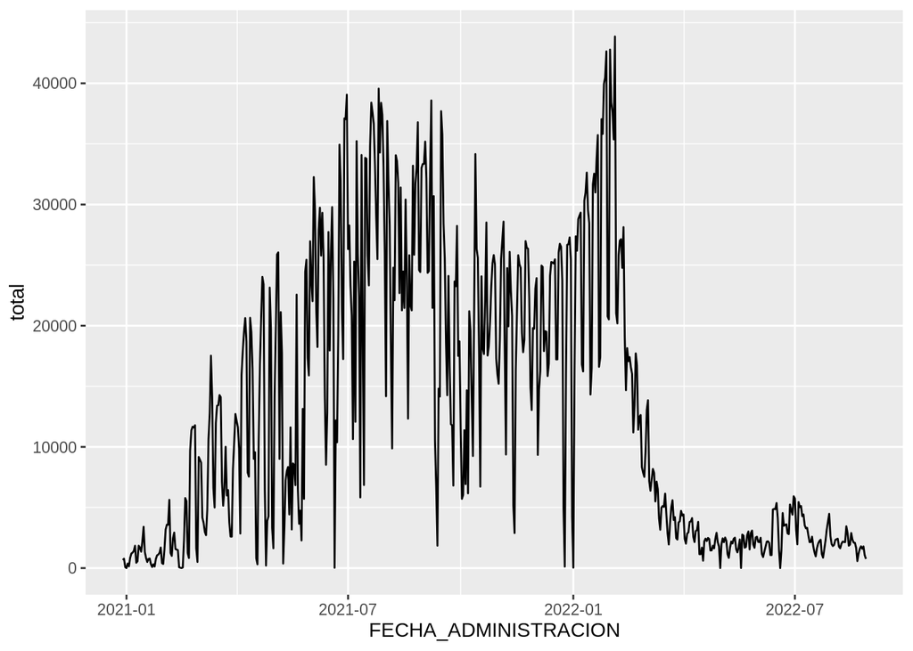

```r
vacunas %>% count(FECHA_ADMINISTRACION, wt = total, name = "total") %>%
  ggplot(aes(FECHA_ADMINISTRACION, total)) +
  geom_line()
```

#### *total* por *día*

#### **geom_line**

#### **geom_smooth**

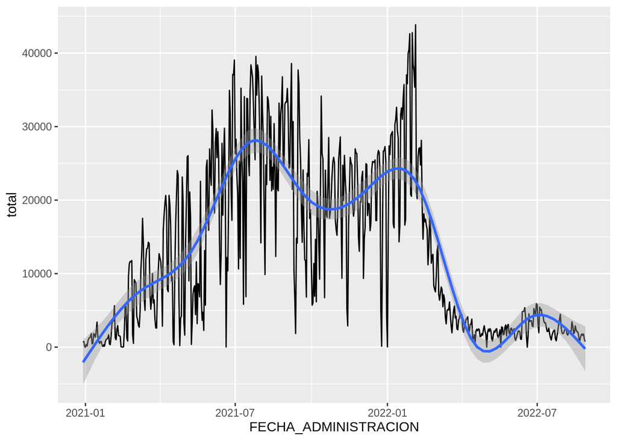

```r
vacunas %>% count(FECHA_ADMINISTRACION, wt = total, name = "total") %>%
  ggplot(aes(FECHA_ADMINISTRACION, total)) +
  geom_line() +
  geom_smooth(method = "gam")
```

#### *total* por *día*

#### **geom_line**

#### **colour**

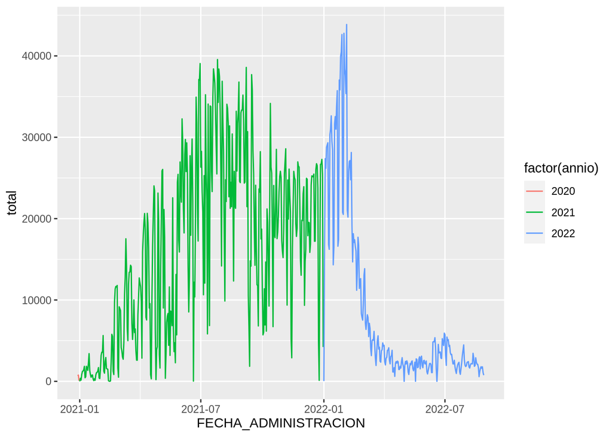

```r
vacunas %>% mutate(annio = year(FECHA_ADMINISTRACION)) %>%
  count(FECHA_ADMINISTRACION, annio, wt = total, name = "total") %>%
  ggplot(aes(FECHA_ADMINISTRACION, total, colour = factor(annio))) +
  geom_line()
```

#### *total* por *semana*

#### **count**

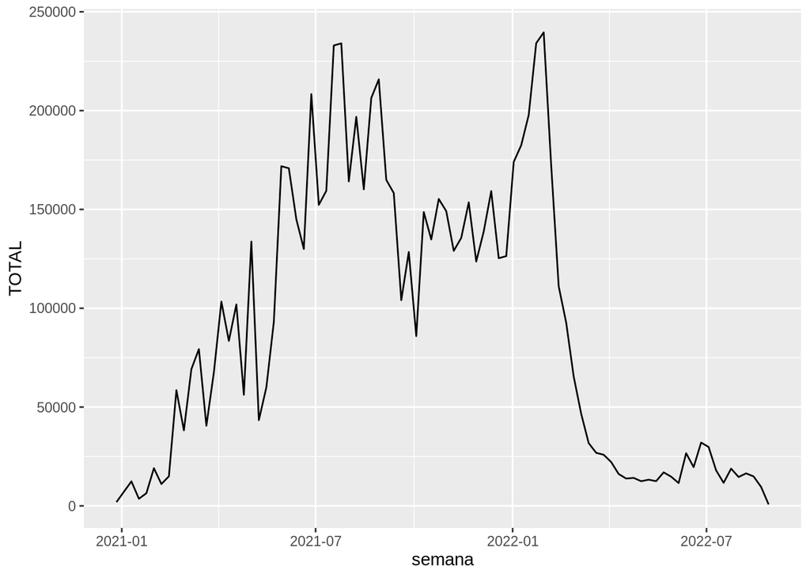

```r
vacunas %>% mutate(semana = floor_date(FECHA_ADMINISTRACION, "week")) %>%
  count(semana, wt = total, name = "TOTAL") %>%
  ggplot(aes(semana, TOTAL)) +
    geom_line()
```

#### *total* por *semana*

#### **group_by**

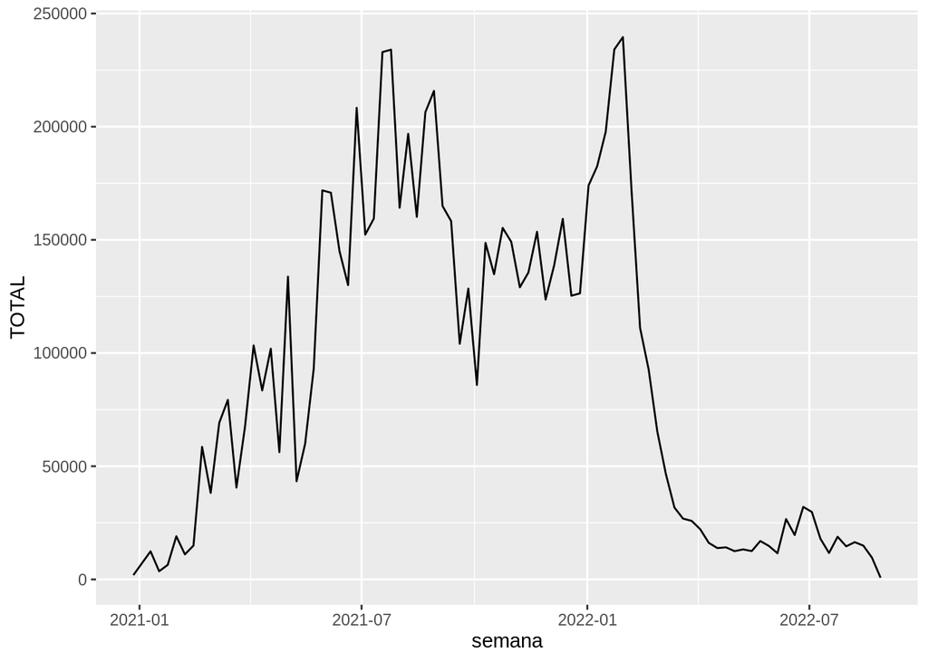

```r
vacunas %>% mutate(semana = floor_date(FECHA_ADMINISTRACION, "week")) %>%
  group_by(semana) %>%
  summarise(TOTAL = sum(total)) %>%
  ggplot(aes(semana, TOTAL)) +
  geom_line()
```

#### *total* por *mes*

#### **geom_line**

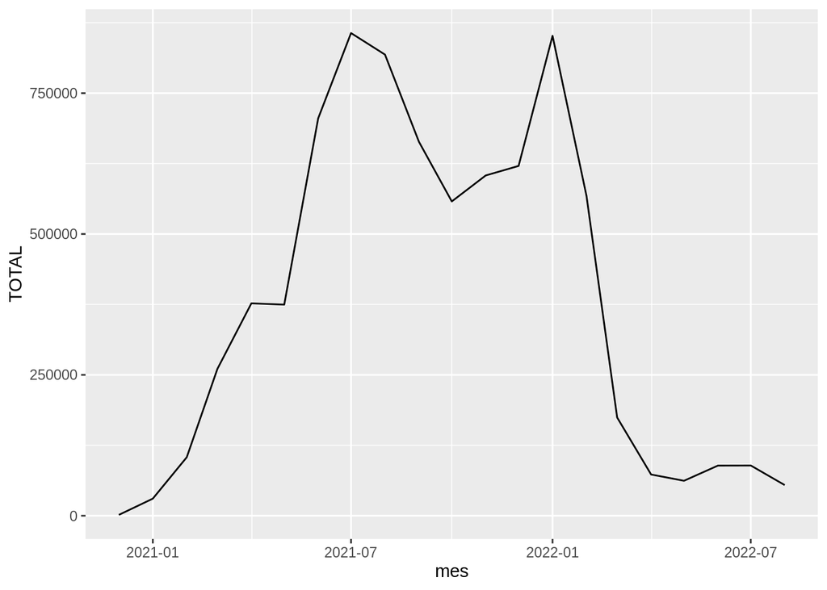

```r
vacunas %>% mutate(mes = floor_date(FECHA_ADMINISTRACION, "month")) %>%
  count(mes, wt = total, name = "TOTAL") %>%
  ggplot(aes(mes, TOTAL)) +
  geom_line()
```

#### *total* por *mes*

#### **geom_bar**

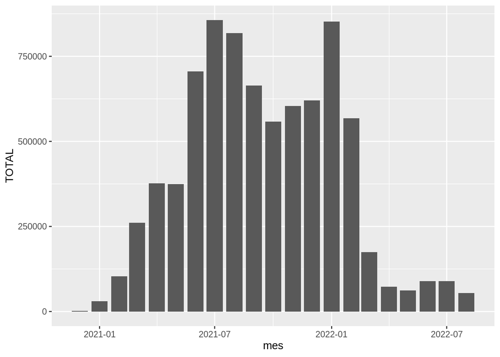

```r
vacunas %>% mutate(mes = floor_date(FECHA_ADMINISTRACION, "month")) %>%
  count(mes, wt = total, name = "TOTAL") %>%
  ggplot(aes(mes, TOTAL)) +
  geom_bar(stat = "identity")
```

### Grabar data frames

#### [familia **readr::write_*()**](https://readr.tidyverse.org/reference/write_delim.html)

##### Guarda un data frame en un archivo de texto donde las columnas son delimitadas por un caracter, por ejemplo “**,**” ó “**;**”

##### Las funciones **write_*()** agregan mejoras a las del tipo *write.csv()*. En primer lugar son más rápidas.

##### **delim** = el delimitador

##### en write_delim es ” ”

##### en write_csv es “,”

##### en write_csv2 es “;”

##### **append** = Si es FALSE, sobre escribe cualquier archivo existente. Si es TRUE, agrega los registros al final.

##### En ambos casos, si el archivo no existe lo crea.

##### **col_names** = Si es FALSE no se agregan los nombres de columna en la primera fila, si es TRUE sí se agregan.

##### El valor tiene que ser lo contrario de lo que se pase en append.

##### **quote** = En que casos entrecomillar los valores.

##### ‘needed’ : solo si es necesario ( cuando el valor incluye comillas, el delimitador o saltos de linea)

##### ‘all’ : entrecomillar todas las columnas

##### ‘none’ : ninguno

##### **escape** = El tipo de escape a usar cuando hay comillas en los datos.

##### ‘double’ : “”

##### ‘backslash’ : \

##### ‘none’ : ninguno

### Guardar gráficos

#### [**ggsave**](https://ggplot2.tidyverse.org/reference/ggsave.html)

### Rscript

```
>R.home() \bin\
C:\Program Files\R\R-4.2.1\bin\Rscript.exe
```

### Un script que descarga los datos y graba los gráficos

#### *crear_graficos.R* :

```
library(dplyr)
library(lubridate)
library(readr)
library(ggplot2)

vacunas <- read_csv("https://cdn.buenosaires.gob.ar/datosabiertos/datasets/salud/plan-de-vacunacion-covid-19/dataset_total_vacunas.csv")

vacunas[which(is.na(vacunas$DOSIS_3)), "DOSIS_3"] <- 0

# Agrego la columna de *total* para cada registro
vacunas <- vacunas %>% mutate(total = (DOSIS_1 + DOSIS_2 + DOSIS_3))

# FECHA_ADMINISTRACION con *lubridate*
# siempre uso el tipo más simple posible, en este caso **date** por sobre **date-time** ya que la hora no la preciso
vacunasXdia <- vacunas %>%
  mutate(FECHA_ADMINISTRACION = as_date(dmy_hms(FECHA_ADMINISTRACION))) %>%
  mutate(annio = year(FECHA_ADMINISTRACION)) %>%
  count(FECHA_ADMINISTRACION, annio, wt = total, name = "total")

# calculo vacunas x año
vacunasXannio <- vacunasXdia %>% count(annio, wt = total)
# grabo en un archivo delimitado por ","
write_csv(vacunasXannio, "vacunasXannio.csv")

p1 <- vacunasXdia  %>%
  ggplot(aes(FECHA_ADMINISTRACION, total, colour = factor(annio))) +
  geom_line()

ggsave(filename =  "vacunas300.png", plot = p1, device = "png", dpi = 300)

ggsave(filename =  "vacunas200.png", plot = p1, device = "png", dpi = 200)

ggsave(filename =  "vacunas100.png", plot = p1, device = "png", dpi = 100)
```

### Para presentación de tablas:

#### [*GT*](https://gt.rstudio.com/)

#### [*kableExtra*](https://haozhu233.github.io/kableExtra/)

#### [RDocumentation *kableExtra*](https://www.rdocumentation.org/packages/kableExtra/versions/1.3.4)

### *GT*

```r
library(gt)

t1 <- vacunas %>% count(GENERO, wt = total, name = "APLICADAS") %>%
  gt() %>%
  tab_header(
    title = "Vacunas por género",
  ) %>%
  tab_source_note("Fuente : www.databuenosaires.gob.ar")

t1
```

Vacunas por género

| GENERO | APLICADAS |
| --- | --- |
| F | 4287537 |
| M | 3648362 |
| N | 48 |

Fuente : www.databuenosaires.gob.ar

### *kableExtra*

```r
library(kableExtra)

t2 <- vacunas %>% count(GENERO, wt = total, name = "APLICADAS") %>%
  kbl(caption = "Vacunas por género", center = TRUE) %>%
  kable_styling(bootstrap_options = "striped", full_width = F) %>%
  footnote(general_title = "Notas", c("Fuente: www.databuenosaires.gob.ar"))

t2
```

Vacunas por género

| GENERO | APLICADAS |
| --- | --- |
| F | 4287537 |
| M | 3648362 |
| N | 48 |

Notas  
Fuente: www.databuenosaires.gob.ar

```r
library(stringr)
```

### [**stringr**](https://stringr.tidyverse.org/)

#### las funciones comienzan con str_ y reciben un vector de strings como primer argumento

- ```r
  str_length("Cuso R")
  ```

  ```
  ## [1] 6
  ```

  ```r
  x <- c("why", "video", "cross", "extra", "deal", "authority")

  str_view_all(x, "[aeiou]")
  ```

[interactive chart not shown]

#### str_detect

- ```r
  # verdadero si hay alguna coincidencia, false en caso contrario
  str_detect(x, "[aeiou]")
  ```

  ```
  ## [1] FALSE  TRUE  TRUE  TRUE  TRUE  TRUE
  ```

#### str_count

- ```r
  # cuenta la cantidad de coincidencias
  str_count(x, "[aeiou]")
  ```

  ```
  ## [1] 0 3 1 2 2 4
  ```

#### str_subset

- ```r
  # extrae los componentes que tienen coincidencias
  str_subset(x, "[aeiou]")
  ```

  ```
  ## [1] "video"     "cross"     "extra"     "deal"      "authority"
  ```

#### str_locate

- ```r
  # la posición de la coincidencias
  str_locate(x, "[aeiou]")
  ```

  ```
  ##      start end
  ## [1,]    NA  NA
  ## [2,]     2   2
  ## [3,]     3   3
  ## [4,]     1   1
  ## [5,]     2   2
  ## [6,]     1   1
  ```

#### str_replace

- ```r
  str_replace(x, "[aeiou]", "?")
  ```

  ```
  ## [1] "why"       "v?deo"     "cr?ss"     "?xtra"     "d?al"      "?uthority"
  ```

#### str_extract

- ```r
  # extrae el texto que coincide
  str_view(x, "r[aeiou]")
  ```

[interactive chart not shown]

  ```r
  str_extract(x, "r[aeiou]")
  ```

  ```
  ## [1] NA   NA   "ro" "ra" NA   "ri"
  ```

  ```r
  str_locate(x, "r[aeiou]")
  ```

  ```
  ##      start end
  ## [1,]    NA  NA
  ## [2,]    NA  NA
  ## [3,]     2   3
  ## [4,]     4   5
  ## [5,]    NA  NA
  ## [6,]     6   7
  ```

#### Otros ejemplos:

- ```r
  x <- c("PALERMO", "BALVANERA", "Barracas", "San Telmo", "CABALLITO", "PARQUE PATRICIOS")
  str_view_all(x, "[aeiou]")
  ```

[interactive chart not shown]

  ```r
  str_view_all(x, "(?i)[aeiou]")
  ```

[interactive chart not shown]

  ```r
  str_view_all(x, "^B")
  ```

[interactive chart not shown]

  ```r
  str_view_all(x, "[Oo]$")
  ```

[interactive chart not shown]

  ```r
  str_subset(x, "[Oo]$")
  ```

  ```
  ## [1] "PALERMO"   "San Telmo" "CABALLITO"
  ```

  ```r
  str_subset(x, " ")
  ```

  ```
  ## [1] "San Telmo"        "PARQUE PATRICIOS"
  ```

  ```r
  str_to_lower(x)
  ```

  ```
  ## [1] "palermo"          "balvanera"        "barracas"         "san telmo"
  ## [5] "caballito"        "parque patricios"
  ```

  ```r
  str_to_upper(x)
  ```

  ```
  ## [1] "PALERMO"          "BALVANERA"        "BARRACAS"         "SAN TELMO"
  ## [5] "CABALLITO"        "PARQUE PATRICIOS"
  ```

  ```r
  str_to_title(x)
  ```

  ```
  ## [1] "Palermo"          "Balvanera"        "Barracas"         "San Telmo"
  ## [5] "Caballito"        "Parque Patricios"
  ```

  ```r
  str_to_sentence(x)
  ```

  ```
  ## [1] "Palermo"          "Balvanera"        "Barracas"         "San telmo"
  ## [5] "Caballito"        "Parque patricios"
  ```

#### la variable VACUNA

```r
vacunas %>% count(VACUNA)
```

```
## # A tibble: 7 × 2
##   VACUNA                                                                  n
##   <chr>                                                               <int>
## 1 AstraZeneca                                                          9161
## 2 Moderna                                                              5240
## 3 Sinopharm                                                            6791
## 4 Sputnik                                                             10315
## 5 vacuna Coronavirus (CANSINO), vial x 1 dosis                         1691
## 6 vacuna Coronavirus (PFIZER) 1ra - 2da dosis, vial x 6 dosis (0.3ml)  4981
## 7 vacuna Coronavirus (PFIZER) pediátrica, vial x 10 dosis (0.2ml)       352
```

```r
vacunas %>% count(VACUNA) %>% .$VACUNA
```

```
## [1] "AstraZeneca"
## [2] "Moderna"
## [3] "Sinopharm"
## [4] "Sputnik"
## [5] "vacuna Coronavirus (CANSINO), vial x 1 dosis"
## [6] "vacuna Coronavirus (PFIZER) 1ra - 2da dosis, vial x 6 dosis (0.3ml)"
## [7] "vacuna Coronavirus (PFIZER) pediátrica, vial x 10 dosis (0.2ml)"
```

```r
strvacunas <- vacunas %>% count(VACUNA) %>% .$VACUNA
```

#### Donde diga “Coronavirus”

```r
# Ver las coincidencias con el patron de búsqueda , útil para afinar la búsqueda.
str_view_all(strvacunas, "Coronavirus")
```

[interactive chart not shown]

```r
# Filtrar por un patron de búsqueda
strvacunas[str_which(strvacunas, "Coronavirus")]
```

```
## [1] "vacuna Coronavirus (CANSINO), vial x 1 dosis"
## [2] "vacuna Coronavirus (PFIZER) 1ra - 2da dosis, vial x 6 dosis (0.3ml)"
## [3] "vacuna Coronavirus (PFIZER) pediátrica, vial x 10 dosis (0.2ml)"
```

```r
# Extraer las coincidencias con el patron de búsqueda
str_extract(strvacunas, "Coronavirus")
```

```
## [1] NA            NA            NA            NA            "Coronavirus"
## [6] "Coronavirus" "Coronavirus"
```

#### Ahora usemos patrones de búsqueda más generales

#### Un dígito seguido de dos caracteres de letras

```r
# Vemos si las ocurrencias son las que esperamos.
str_view_all(strvacunas, "\\d\\w\\w")
```

[interactive chart not shown]

```r
# Podemos filtrar
strvacunas[str_which(strvacunas, "\\d\\w\\w")]
```

```
## [1] "vacuna Coronavirus (PFIZER) 1ra - 2da dosis, vial x 6 dosis (0.3ml)"
## [2] "vacuna Coronavirus (PFIZER) pediátrica, vial x 10 dosis (0.2ml)"
```

```r
# También podemos extraer
str_extract(strvacunas, "\\d\\w\\w")
```

```
## [1] NA    NA    NA    NA    NA    "1ra" "2ml"
```

#### Extraer todas las ocurrencias

```r
str_extract_all(strvacunas, "\\d\\w\\w")
```

```
## [[1]]
## character(0)
##
## [[2]]
## character(0)
##
## [[3]]
## character(0)
##
## [[4]]
## character(0)
##
## [[5]]
## character(0)
##
## [[6]]
## [1] "1ra" "2da" "3ml"
##
## [[7]]
## [1] "2ml"
```

#### Uno o más letras entre paréntesis

```r
str_view_all(strvacunas, "\\(\\w+\\)")
```

[interactive chart not shown]

```r
str_extract_all(strvacunas, "\\(\\w+\\)")
```

```
## [[1]]
## character(0)
##
## [[2]]
## character(0)
##
## [[3]]
## character(0)
##
## [[4]]
## character(0)
##
## [[5]]
## [1] "(CANSINO)"
##
## [[6]]
## [1] "(PFIZER)"
##
## [[7]]
## [1] "(PFIZER)"
```

#### Uno o más, letras en mayúscula, entre paréntesis

```r
str_view_all(strvacunas, "\\([:upper:]+\\)")
```

[interactive chart not shown]

```r
str_extract_all(strvacunas, "\\([:upper:]+\\)")
```

```
## [[1]]
## character(0)
##
## [[2]]
## character(0)
##
## [[3]]
## character(0)
##
## [[4]]
## character(0)
##
## [[5]]
## [1] "(CANSINO)"
##
## [[6]]
## [1] "(PFIZER)"
##
## [[7]]
## [1] "(PFIZER)"
```

#### 4 o más, letras en mayúscula, juntas.

```r
str_view_all(strvacunas, "[:upper:]{4,}")
```

[interactive chart not shown]

```r
str_extract_all(strvacunas, "[:upper:]{4,}")
```

```
## [[1]]
## character(0)
##
## [[2]]
## character(0)
##
## [[3]]
## character(0)
##
## [[4]]
## character(0)
##
## [[5]]
## [1] "CANSINO"
##
## [[6]]
## [1] "PFIZER"
##
## [[7]]
## [1] "PFIZER"
```

#### Finalmente, lo que queriamos hacer es extraer para cada registro de vacuna un nombre de vacuna.

#### Uno o más caracteres entre A y Z, ó “AstraZeneca ó …

#### Luego le saco los paréntesis

#### Y termino pasando todo a mayusculas.

```r
vacunas %>% count(VACUNA) %>% .$VACUNA  %>%
str_extract(pattern =  "\\([A-Z]+\\)|AstraZeneca|Sinopharm|Moderna|Sputnik") %>%
  str_replace_all("\\(|\\)", "") %>%
  str_to_upper()
```

```
## [1] "ASTRAZENECA" "MODERNA"     "SINOPHARM"   "SPUTNIK"     "CANSINO"
## [6] "PFIZER"      "PFIZER"
```

#### Asignando en una nueva variable

```r
vacunas$VAC <-  vacunas$VACUNA %>%
  str_extract( pattern =  "\\([A-Z]+\\)|AstraZeneca|Sinopharm|Moderna|Sputnik") %>%
  str_replace_all("\\(|\\)", "") %>% str_to_upper()
```

#### con **mutate**

```r
vacunas %>% mutate(VAC = VACUNA %>%
                     str_extract( pattern =  "\\([A-Z]+\\)|AstraZeneca|Sinopharm|Moderna|Sputnik") %>%
                     str_replace_all("\\(|\\)", "") %>% str_to_upper()) %>%
                  select(FECHA_ADMINISTRACION, GRUPO_ETARIO, GENERO, VAC, total)
```

```
## # A tibble: 38,531 × 5
##    FECHA_ADMINISTRACION GRUPO_ETARIO GENERO VAC     total
##    <date>               <chr>        <chr>  <chr>   <dbl>
##  1 2021-01-14           41 a 50      M      SPUTNIK   138
##  2 2021-01-14           41 a 50      M      SPUTNIK    28
##  3 2021-01-14           51 a 60      F      SPUTNIK    54
##  4 2021-01-14           51 a 60      F      SPUTNIK   173
##  5 2021-01-14           51 a 60      F      SPUTNIK    27
##  6 2021-01-14           51 a 60      M      SPUTNIK    27
##  7 2021-01-14           51 a 60      M      SPUTNIK    82
##  8 2021-01-14           51 a 60      M      SPUTNIK    12
##  9 2021-01-14           61 a 70      F      SPUTNIK     1
## 10 2021-01-15           30 o menos   F      SPUTNIK   157
## # … with 38,521 more rows
```

#### Ahora se muestra mejor la variabla

```r
vacunas %>% count(VAC, wt = total, name = "DOSIS")
```

```
## # A tibble: 6 × 2
##   VAC           DOSIS
##   <chr>         <dbl>
## 1 ASTRAZENECA 2034767
## 2 CANSINO       70670
## 3 MODERNA      795907
## 4 PFIZER      1569444
## 5 SINOPHARM   1955134
## 6 SPUTNIK     1510025
```

### Bibliografia:

#### [R para Ciencia de Datos - Cap 16 Fechas y horas](https://es.r4ds.hadley.nz/fechas-y-horas.html#fechas-y-horas)

#### [R para Ciencia de Datos - Cap 14 Cadenas de caracteres](https://es.r4ds.hadley.nz/cadenas-de-caracteres.html#cadenas-de-caracteres)

clase04.R